# Model confusion

# Setup

```r
workflow_name <- "netnav_05_model_confusion"

library(tidyverse)
library(here)
```

```r
library(broom)
library(patchwork)

source(here("code", "utils", "ggplot_themes.R"))
source(here("code", "utils", "kable_utils.R"))
source(here("code", "utils", "bayesian_model_selection.R"))

knitting <- knitr::is_html_output()

create_path <- function(this_path) {
  if (!dir.exists(this_path)) {
    dir.create(this_path, recursive = TRUE)
  }
}

if (knitting) {
  here("outputs", workflow_name) %>%
    create_path()

  here("figures") %>%
    create_path()
}
```

```r
params <- here("data", "model_confusion") %>%
  fs::dir_ls(
    regexp = "(bfs_(backward|forward)|ideal_obs|sr)(.)+\\.csv",
    recurse = 1
  ) %>%
  map_dfr(.f = ~read_csv(.x, show_col_types = FALSE), .id = "filename") %>%
  mutate(
    sub_id = str_extract(filename, "sub_[[:digit:]]+"),
    sub_id = str_remove(sub_id, "sub_"),
    sub_id = as.numeric(sub_id),
    fit_model = str_extract(
      filename, "fit_model_(bfs_(backward|forward)|ideal_obs|sr)"
    ),
    fit_model = str_remove(fit_model, "fit_model_"),
    true_model = str_extract(
      filename, "true_model_(bfs_(backward|forward)|ideal_obs|sr)"
    ),
    true_model = str_remove(true_model, "true_model_")
  ) %>%
  select(sub_id, everything(), -filename) %>%
  rename(neg_loglik = optim_value) %>%
  # Find best-fitting optimization run
  filter(convergence == "converged") %>%
  group_by(sub_id, fit_model, true_model) %>%
  slice_min(neg_loglik, n = 1) %>%
  ungroup() %>%
  # Some subjects may have had multiple "best" optimization runs
  # In that case, just go with whichever "best" run was estimated first
  group_by(sub_id, fit_model, true_model) %>%
  slice_min(optimizer_run, n = 1) %>%
  ungroup()
```

# Compute AICc

We’ll use AICc (AIC corrected for small n) to determine which model “best” fits each agent’s behavior.

```r
aicc <- params %>%
  select(sub_id, true_model, fit_model, neg_loglik) %>%
  distinct() %>%
  arrange(sub_id, true_model, fit_model) %>%
  mutate(
    n_params = if_else(fit_model == "sr", 2, 1),
    n_datapoints = 115,
    aic = (-2 * -neg_loglik) + (2 * n_params),
    aicc = aic + (
      (2 * n_params * (n_params + 1)) / (n_datapoints - n_params - 1)
    )
  )

best_fitting_model_per_agent <- aicc %>%
  group_by(sub_id, true_model) %>%
  slice_min(aicc, n = 1) %>%
  ungroup() %>%
  select(sub_id, true_model, best_fitting_model = fit_model)
```

# Confusion matrix

The confusion matrix specifies $p(\text{fit model} = Y \vert \text{true model} = X)$. Ideally, we would want large probabilities on the diagonal, and small probabilities otherwise. This analysis indicates that confusability is relatively high for the SR model, but relatively low for other models.

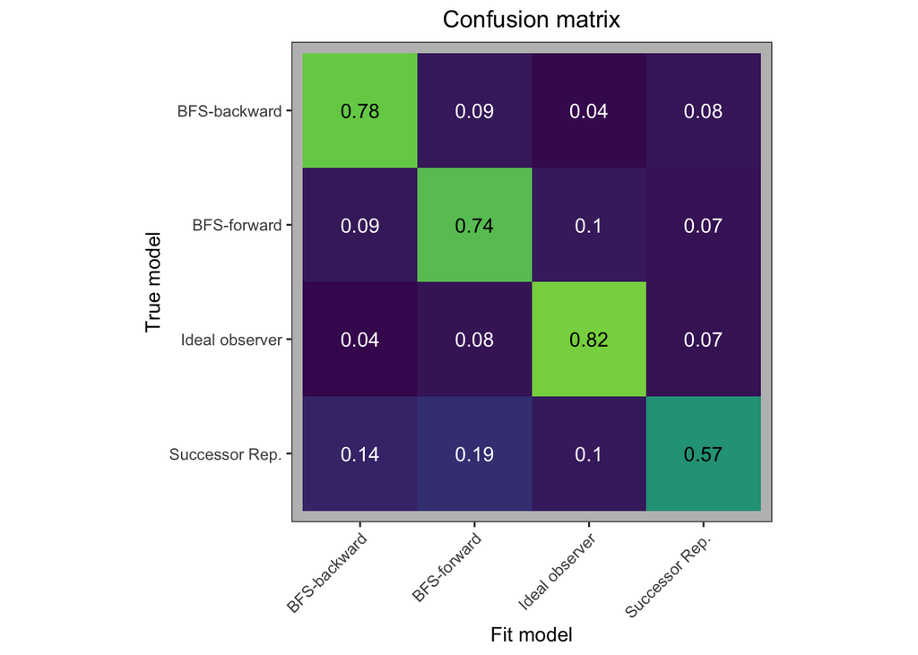

```r
plot_confusion_matrix <- aicc %>%
  group_by(sub_id, true_model) %>%
  mutate(best_model = aicc == min(aicc)) %>%
  ungroup() %>%
  group_by(true_model, fit_model) %>%
  summarise(p = mean(best_model), .groups = "drop") %>%
  # Plotting
  mutate(
    across(
      c(true_model, fit_model),
      ~case_when(
        .x == "bfs_backward" ~ "BFS-backward",
        .x == "bfs_forward" ~ "BFS-forward",
        .x == "ideal_obs" ~ "Ideal observer",
        .x == "sr" ~ "Successor Rep."
      )
    ),
    true_model = fct_rev(true_model)
  ) %>%
  ggplot(aes(x=fit_model, y=true_model, fill=p)) +
  theme_heatmap() +
  geom_tile(show.legend = FALSE) +
  geom_text(aes(label = round(p, 2), color = p < .5), show.legend = FALSE) +
  scale_fill_viridis_c(limits = c(0, 1)) +
  scale_color_manual(values = c("FALSE"="black", "TRUE"="white")) +
  coord_fixed() +
  xlab("Fit model") +
  ylab("True model") +
  ggtitle("Confusion matrix") +
  theme(
    axis.text.x = element_text(angle = 45, vjust = 1, hjust = 1),
    legend.position = "bottom"
  )

plot_confusion_matrix
```

```r
if (knitting) {
  ggsave(
    filename = here("outputs", workflow_name, "model_confusion.pdf"),
    plot = plot_confusion_matrix,
    width = 5, height = 5,
    units = "in", dpi = 300
  )
}
```

# Inversion matrix

The inversion matrix specifies $p(\text{true model} = Y \vert \text{fit model} = X)$, and is useful when interpreting parameter estimates from real subjects’ data, as the true model is unknown.

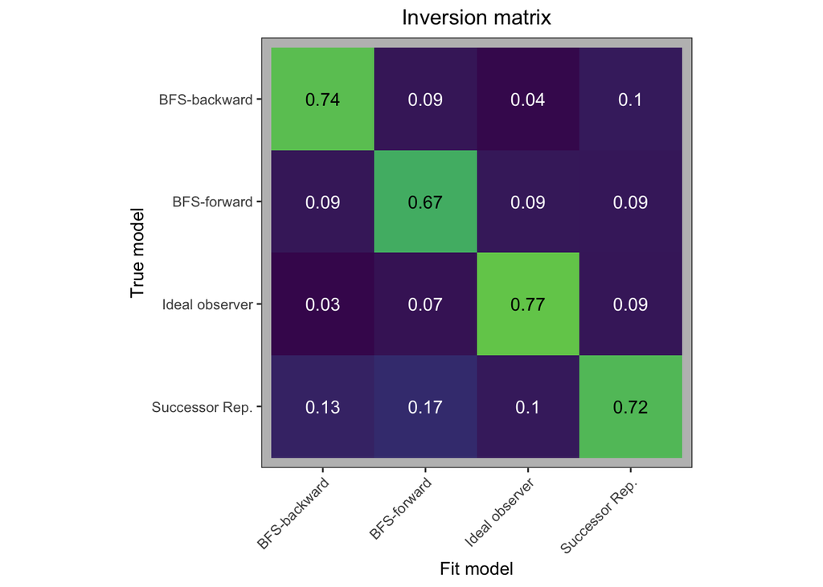

```r
plot_inversion_matrix <- aicc %>%
  group_by(sub_id, true_model) %>%
  mutate(best_model = aicc == min(aicc)) %>%
  ungroup() %>%
  group_by(true_model, fit_model) %>%
  summarise(p = mean(best_model), .groups = "drop") %>%
  # Inversion
  group_by(fit_model) %>%
  mutate(p = p / sum(p)) %>%
  ungroup() %>%
  # Plotting
  mutate(
    across(
      c(true_model, fit_model),
      ~case_when(
        .x == "bfs_backward" ~ "BFS-backward",
        .x == "bfs_forward" ~ "BFS-forward",
        .x == "ideal_obs" ~ "Ideal observer",
        .x == "sr" ~ "Successor Rep."
      )
    ),
    true_model = fct_rev(true_model)
  ) %>%
  ggplot(aes(x=fit_model, y=true_model, fill=p)) +
  theme_heatmap() +
  geom_tile(show.legend = FALSE) +
  geom_text(aes(label = round(p, 2), color = p < .5), show.legend = FALSE) +
  scale_fill_viridis_c(limits = c(0, 1)) +
  scale_color_manual(values = c("FALSE"="black", "TRUE"="white")) +
  coord_fixed() +
  xlab("Fit model") +
  ylab("True model") +
  ggtitle("Inversion matrix") +
  theme(
    axis.text.x = element_text(angle = 45, vjust = 1, hjust = 1),
    legend.position = "bottom"
  )

plot_inversion_matrix
```

```r
if (knitting) {
  ggsave(
    filename = here("outputs", workflow_name, "model_inversion.pdf"),
    plot = plot_inversion_matrix,
    width = 5, height = 5,
    units = "in", dpi = 300
  )
}
```

# PXP

Finally, we might be curious to see whether we can use protected exceedance probability (PXP) to make reliable inferences about the most probable group-level model. Note that this analysis is likely to be over-optimistic, as the simulated data were noise-free.

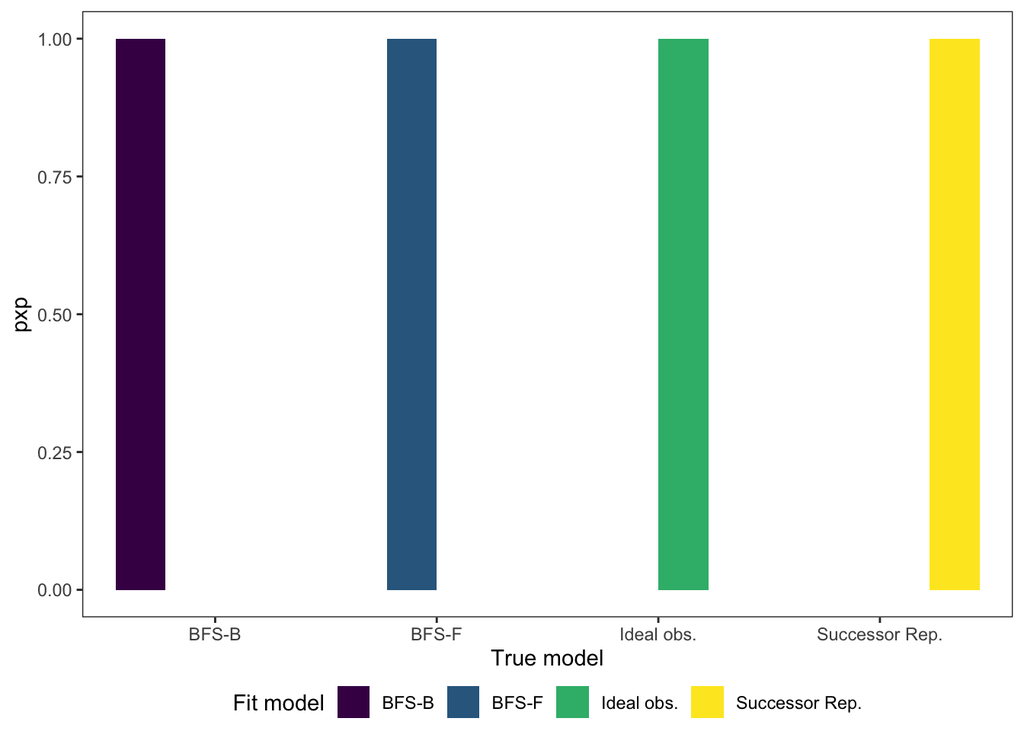

```r
pxp_results <- aicc %>%
  select(sub_id, true_model, fit_model, aicc) %>%
  # In the PXP analysis, more is more, so sign-flip AICc so that greater values
  # indicate better fit
  mutate(aicc = -aicc) %>%
  pivot_wider(names_from = fit_model, values_from = aicc) %>%
  select(-sub_id) %>%
  group_by(true_model) %>%
  nest() %>%
  mutate(
    test = map(
      .x = data,
      .f = ~bayesian_model_selection(.x)
    )
  ) %>%
  unnest(test) %>%
  ungroup() %>%
  select(-data)

plot_pxp <- pxp_results %>%
  mutate(
    across(
      c(true_model, model),
      ~case_when(
        .x == "bfs_backward" ~ "BFS-B",
        .x == "bfs_forward" ~ "BFS-F",
        .x == "ideal_obs" ~ "Ideal obs.",
        .x == "sr" ~ "Successor Rep."
      )
    )
  )  %>%
  ggplot(aes(x=true_model, y=pxp, fill=model)) +
  theme_custom() +
  geom_col(position = "dodge") +
  scale_fill_viridis_d(name = "Fit model") +
  xlab("True model") +
  theme(legend.position = "bottom")

plot_pxp
```

```r
if (knitting) {
  ggsave(
    filename = here("outputs", workflow_name, "pxp.pdf"),
    plot = plot_pxp,
    width = 5, height = 2.5,
    units = "in", dpi = 300
  )
}
```

# Figure for supplement

In the supplement, we’ll want a plot of both the confusion and inversion matrices.

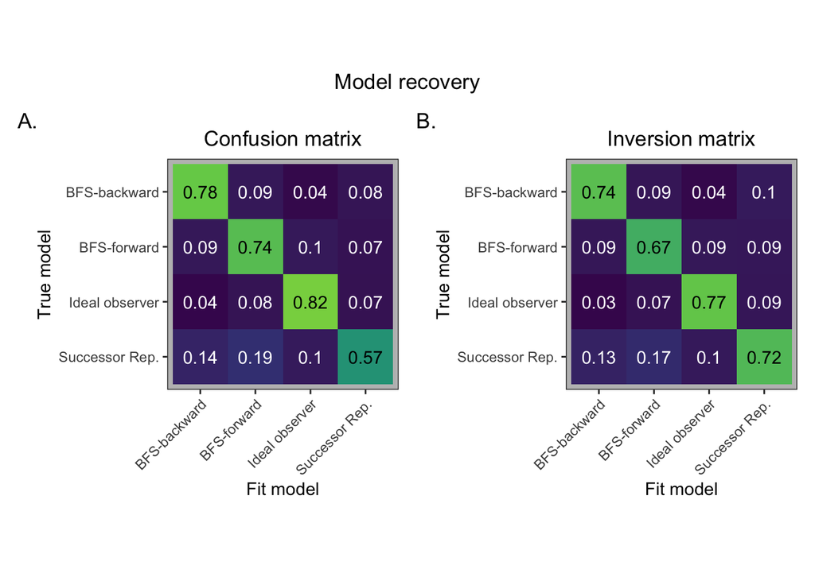

```r
plot_confusion_for_supp <- wrap_plots(
  plot_confusion_matrix,
  plot_inversion_matrix,
  nrow = 1
) +
  plot_annotation(
    title = "Model recovery",
    theme = theme(plot.title = element_text(hjust = 0.5)),
    tag_levels = "A", tag_suffix = "."
  )

plot_confusion_for_supp
```

```r
if (knitting) {
  ggsave(
    filename = here("figures", "supp_model_recovery.pdf"),
    plot = plot_confusion_for_supp,
    width = 8, height = 4,
    units = "in", dpi = 300
  )
}
```